# La Política de la Corrupción

Sesión 6: El patronazgo y la Era Progresista en Estados Unidos

Bogdan G. Popescu

bgpopescu@tec.mx

Tecnológico de Monterrey

## ¿Qué acaba de pasar?

- Diego trabajó tres meses de tardes y no le pagaron nada
- El partido ganó, y un puesto público quedó disponible
- No hubo dinero de por medio. Nada se ocultó. Nadie se avergonzó

Él pagó con **tardes**. El partido pagó con un **empleo público**.

Este arreglo tiene nombre: **patronazgo** — empleos públicos repartidos como recompensa por apoyo político, y no por saber hacer el trabajo.

**¿Eso es corrupción?**

## Repartir contratos públicos

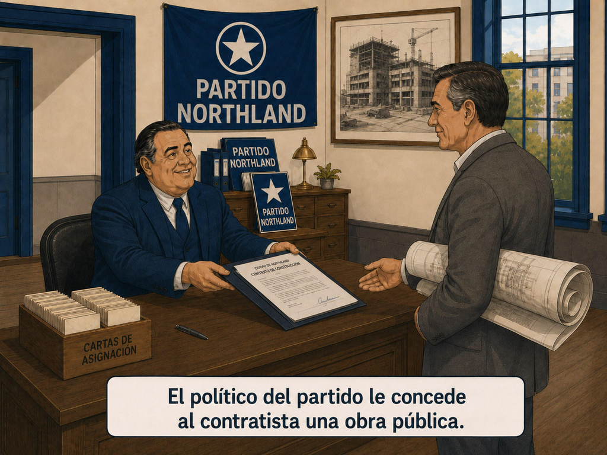

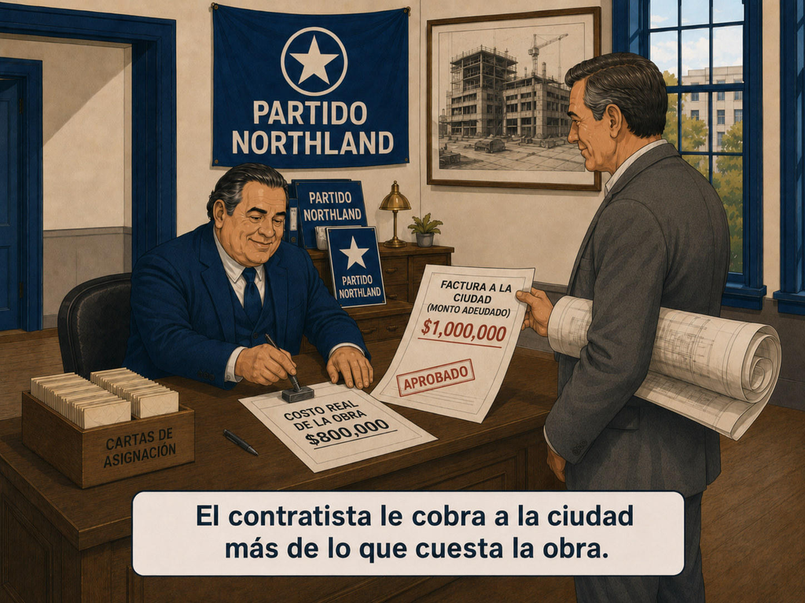

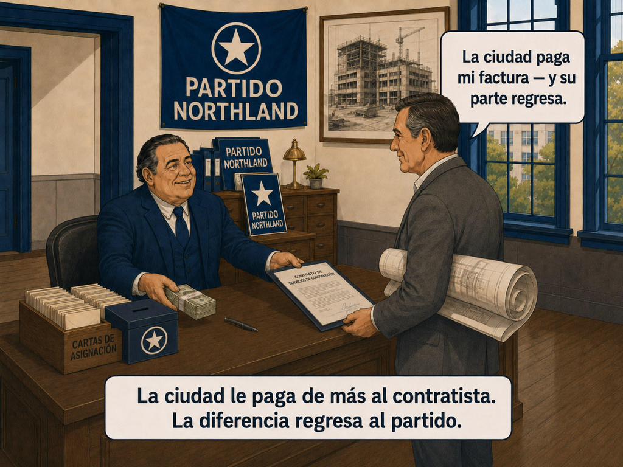

Una empresa privada recibe el contrato para remodelar un hospital público.

**¿Esto es corrupción?**

La obra cuesta **$800,000**. A la ciudad le facturan **$1,000,000**.

La ciudad paga los **$200,000** de más — con dinero público.

El contratista es hermano del alcalde — y parte de esos $200,000 regresa al partido.

**Nadie le pidió un soborno a ningún ciudadano. El público pagó las dos.**

## El acertijo — y la ruta de hoy

Diego trabaja para el partido y recibe un empleo público.

Un contratista le factura de más a la ciudad y devuelve parte de ese dinero al partido.

Lo segundo se parece a la corrupción de siempre. **¿Pero y si lo primero es perfectamente legal?** Los dos arreglos usan recursos públicos para sostener el poder político. Entonces, ¿cómo hay que pensarlos — y cómo se rompen?

**Cuatro preguntas:**

1. ¿Qué tipo de corrupción es cada una?
2. ¿Se puede quitar el favor que los políticos venden?
3. Si el favor tiene que seguir existiendo, ¿se puede quitar la discrecionalidad de los políticos sobre quién lo recibe?
4. Cuando la reforma hizo eso, ¿cambió realmente el comportamiento del gobierno?

## La corrupción no se reparte por igual

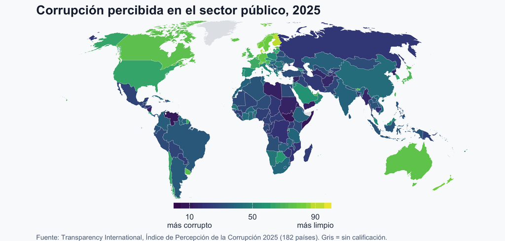

## Dónde queda cada país

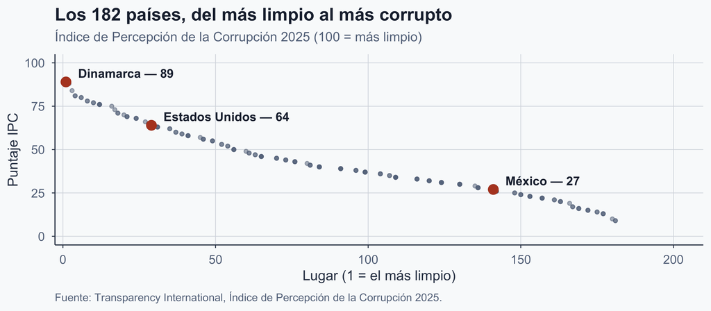

Hoy Estados Unidos está **relativamente limpio para los estándares mundiales — aunque lejos de estar libre de corrupción.**

## Estados Unidos no empezó limpio

- Nueva York, 1871: el mismo arreglo, a escala de toda la ciudad
- Hasta la policía estaba metida — la acusación tuvo que venir del estado

No era un funcionario deshonesto. Era un **sistema** — por eso quitar a un solo hombre no lo habría arreglado.

**¿Puede un país reducir la corrupción de manera sustancial una vez que ya está incrustada en su sistema político?** Estados Unidos es un caso que sí podemos observar.

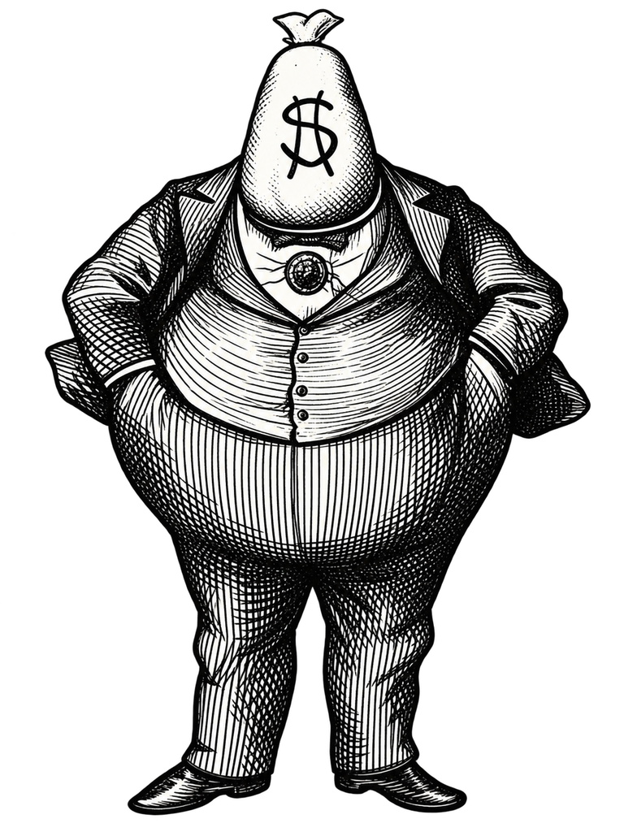

El jefe de la maquinaria, William “Boss” Tweed, dibujado por Thomas Nast, *Harper’s Weekly*, 1871. Sobre la acusación proveniente del estado y no de la ciudad, véase Glaeser y Goldin (2006, p. 12). Library of Congress.

## ¿Quién fue el “Boss” Tweed?

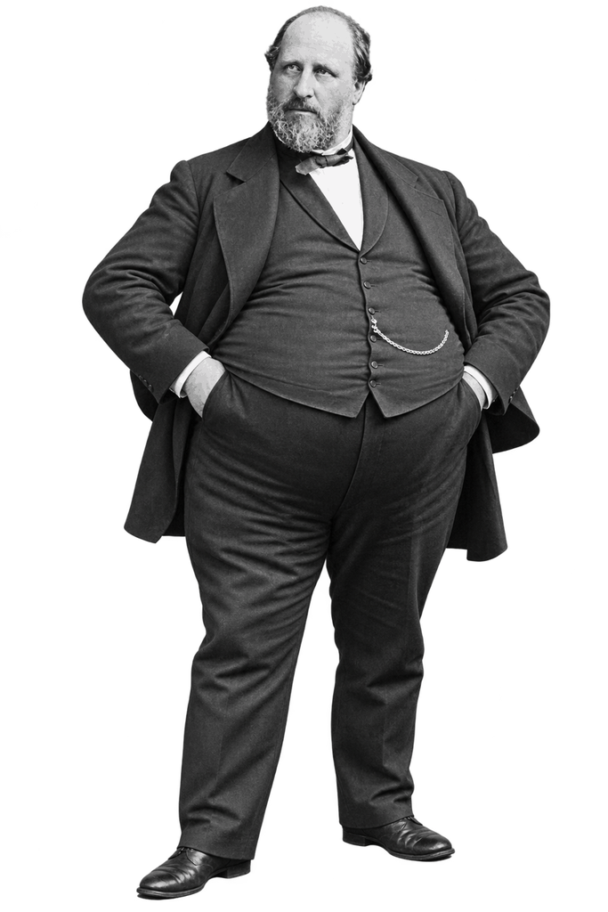

- William M. Tweed, 1823–1878, Nueva York
- **Nunca fue alcalde.** Presidía Tammany Hall, la organización del Partido Demócrata en la ciudad
- Su poder venía de dirigir el **partido**, no de ocupar un cargo alto
- Tammany daba a los neoyorquinos pobres y migrantes empleos, carbón y ayuda con trámites — a cambio de sus votos
- Y se quedaba con una tajada de cada contrato de la ciudad

**¿De qué tipo era, entonces?**

Las facturas infladas eran **venales** — ganancia privada con dinero público.

La maquinaria en sí era **sistemática** — empleos y contratos repartidos para mantener a Tammany en el poder.

**Las dos, en una sola organización.**

Tweed fue condenado en 1873 y murió en la cárcel en 1878. **Tammany siguió gobernando Nueva York otros sesenta años.**

La biografía es contexto, no proviene de las lecturas asignadas. Sobre la acusación proveniente del estado y no de la ciudad, véase Glaeser y Goldin (2006, p. 12).

## Lo que Nast realmente dibujó

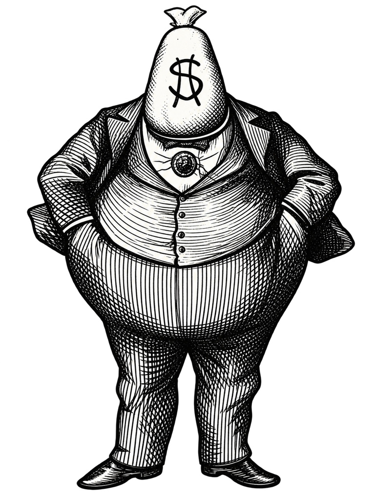

[figure not shown]

- Thomas Nast, *Harper’s Weekly*, 1871
- La cabeza de Tweed está reemplazada por una **bolsa de dinero**
- El chiste no es que fuera codicioso. Es que el “cerebro” detrás de la maquinaria no era la inteligencia: era el **dinero**

Nast publicó estas caricaturas durante meses. Muchos votantes de la maquinaria no sabían leer inglés. Todos podían leer esto.

Aunque quien destapó el escándalo fue un **político rival**, no solo la prensa (Glaeser y Goldin, 2006, p. 12).

Y por eso *él* es el famoso. Otras ciudades tuvieron maquinarias igual de duraderas. No tuvieron a Nast.

## Dos maneras de dibujar al mismo hombre

[figure not shown]

La fotografía. La caricatura. Y el jefe de la oficina del partido donde estuvo Diego.

**Nadie en la primera imagen parece un criminal.** Por eso justamente funcionaba la maquinaria: desde adentro se veía normal, y hizo falta un caricaturista para dibujar lo que en realidad era.

# Parte I — Dos tipos de corrupción

Wallis: la palabra que usamos hoy no es la palabra que ellos usaban.

## Dos tipos de corrupción

**¿Hacia dónde apunta la flecha?**

```
%%{init: {"theme": "base", "width": 1200, "height": 440, "fontSize": 16, "themeVariables": {"fontSize": "16px", "fontFamily": "Helvetica, Arial, sans-serif", "primaryColor": "#eef2f6", "primaryTextColor": "#1e293b", "primaryBorderColor": "#334155", "lineColor": "#b44527", "edgeLabelBackground": "#f9…
flowchart LR
  A["EL CARGO PÚBLICO<br/>el poder de decidir"]
  B["LOS BENEFICIOS ECONÓMICOS<br/>dinero, empleos, contratos"]
  A -- "VENAL<br/>usar el cargo para obtener lucro económico privado" --> B
  B -- "SISTEMÁTICA<br/>usar privilegios económicos para sostener el poder político" --> A
  classDef box fill:#eef2f6,stroke:#334155,stroke-width:2px,color:#1e293b;
  class A,B box;
```

**La lógica política es distinta.**

- **Corrupción venal:** el poder político produce lucro económico privado.
- **Corrupción sistemática:** los privilegios económicos producen apoyo y control político.

La comisión del contratista es venal: **cargo → dinero**. El patronazgo es sistemático: **empleos → apoyo político**. **Las dos, en esa misma oficina.**

“Sistemática” es el término de Wallis; **no** quiere decir “generalizada” — describe cómo la corrupción ayuda a reproducir el poder político (Wallis, 2006, pp. 25–26).

## ¿Es una casilla nueva, o una pregunta nueva?

Ninguna reemplaza lo que ya teníamos. **Cada enfoque hace una pregunta distinta sobre la misma oficina:**

| La pregunta | De dónde viene | Diego y el contratista |
| --- | --- | --- |
| **¿Cuándo** puede un funcionario hacerlo? | monopolio + discrecionalidad − rendición de cuentas | un partido controla los empleos *y* los contratos |
| **¿En qué dirección** va el intercambio? | venal / sistemática *(hoy)* | en las dos, desde el mismo escritorio |
| **¿Por qué** todos participan? | normas y expectativas | nadie lo esconde, nadie se avergüenza |
| **¿Quién** podría detenerlo? | principal–agente vs. acción colectiva | hasta la policía era parte |
| **¿Cuánto** cuesta? | grasa o arena | el público paga los $200,000 de más |

Así que venal/sistemática no es una etiqueta rival. Responde la pregunta que las otras dejan abierta: **¿para qué sirve el intercambio corrupto?**

Klitgaard te dice cuándo un funcionario *puede*. Wallis te dice qué está *haciendo con ello*: llenarse los bolsillos, o mantener a su partido en el poder.

## Ejercicio 1 — ¿De qué tipo?

**En parejas. Venal, sistemática, o las dos — y expliquen por qué.**

1. Un inspector de aduanas exenta un impuesto de importación a cambio de efectivo.
2. Todas las empresas que ganan obra pública en la ciudad también donan al partido gobernante. Nada se oculta — y supongamos que allí es totalmente legal.
3. Un alcalde compra terrenos sobre la ruta del metro antes de que se anuncie.
4. Solo los bancos cuyos directivos apoyan a la facción gobernante reciben concesión.

**Luego, dos preguntas.** ¿Cuáles siguen siendo un problema al día siguiente de encarcelar a todos los involucrados y poner gente honesta en su lugar?

Y supongamos que el número 2 es perfectamente legal. ¿Eso lo vuelve el menos preocupante de la lista — o el más?

## Ejercicio 1 — una sola pregunta los ordena

**¿Qué está comprando el intercambio?**

| Caso | ¿Qué compra? | Tipo |
| --- | --- | --- |
| 1. El inspector recibe el efectivo | un impuesto exentado, y su propio ingreso | **Venal** |
| 2. Las empresas ganadoras donan al partido | que el partido siga en el poder | **Sistemática** |
| 3. El alcalde compra el terreno primero | una ganancia privada | **Venal** |
| 4. Concesiones solo para los aliados de la facción | una coalición que mantiene a la facción en el poder | **Sistemática** |

**No es “quién se hizo más rico”.** Los arreglos sistemáticos también enriquecen a personas — Tweed murió rico. La pregunta es *para qué* sirve el intercambio.

**Ahora encarcelen a todos y pongan gente honesta en cada silla.** El 1 y el 3 necesitan a alguien deshonesto, así que se detienen. El 2 y el 4 siguen igual: el trabajo lo hace el arreglo, no el carácter.

**Y si el número 2 es legal**, eso lo vuelve más difícil de atacar, no más inofensivo: no hay a quién acusar, y el mercado sigue cerrado para todos los que están fuera del círculo.

# Parte II — Quitar lo que hay para vender

Wallis: una solución económica a un problema político.

## Imagina que necesitas el permiso de un político

Imagina que quieres abrir un banco.

Hoy, normalmente cumplirías una serie de requisitos y presentarías la solicitud.

Pero en los primeros años de Estados Unidos, eso no bastaba.

Necesitabas que la legislatura del estado te diera el permiso

Los políticos decidían quién obtenía permiso y quién no

Eso volvía el permiso extremadamente valioso

Quien recibía el favor tenía razones para apoyar a los políticos que se lo dieron

Nadie necesita recibir un maletín de billetes. **El permiso mismo es el favor.**

## ¿Por qué eso es un problema de corrupción?

Imagina que diez personas quieren abrir bancos.

Pero los políticos eligen solo a dos.

- Esos dos reciben algo valioso
- Los otros ocho quedan fuera
- Los ganadores ahora tienen razones para apoyar a los políticos
- Los políticos tienen razones para seguir decidiendo quién entra

El sistema puede sostenerse solo, aunque nadie reciba personalmente un soborno.

Eso es lo que Wallis llama corrupción sistemática.

## Luego el sistema se topó con una crisis

En la década de 1830, muchos gobiernos estatales se endeudaron fuertemente para financiar bancos, canales, ferrocarriles y otras obras.

- De pronto los gobiernos debían cantidades enormes
- Para 1842, ocho estados y Florida habían dejado de pagar parte de su deuda
- Las legislaturas investigaron qué había salido mal
- El robo explicaba algunos casos — pero no la mayoría

El problema de fondo parecían ser las reglas mismas:

- los políticos tenían demasiado poder para decidir quién recibía privilegios económicos valiosos.

La crisis no produjo la reforma por sí sola. Volvió mucho más difícil defender el sistema anterior.

## La jugada: quitar la moneda de cambio

**Antes**

- Quieres abrir una empresa → los políticos deciden si puedes hacerlo.
- El permiso es escaso, así que las conexiones políticas importan.

**Después — constitución general de sociedades**

- Quieres abrir una empresa → cumples los requisitos publicados y puedes hacerlo.
- Los políticos ya no te eligen a ti en particular.
- La reforma no prohibió todos los tratos corruptos.
- Quitó algo con lo que los políticos podían negociar.

Wallis (2006, p. 50), en Glaeser y Goldin, eds., *Corruption and Reform*.

## ¿Y entonces?

- La corrupción sistemática necesita algo valioso que los políticos puedan repartir selectivamente
- La constitución general de sociedades atacó el sistema al quitar la **discrecionalidad de los políticos sobre quién entra**
- La lección no fue “castiguen a los políticos corruptos” — fue **volver el favor imposible de vender**
- Pero los políticos seguían controlando otros bienes escasos
- Sobre todo: **los empleos públicos**

Quita una moneda política, y la pregunta pasa a ser:

**¿qué más puede usar el partido para comprar lealtad?**

# Parte III — Maquinarias, botín y la larga pelea por el mérito

El patronazgo, y la larga discusión sobre cómo terminarlo — la **Era Progresista**, aproximadamente de 1890 a 1920.

## De vuelta con Diego

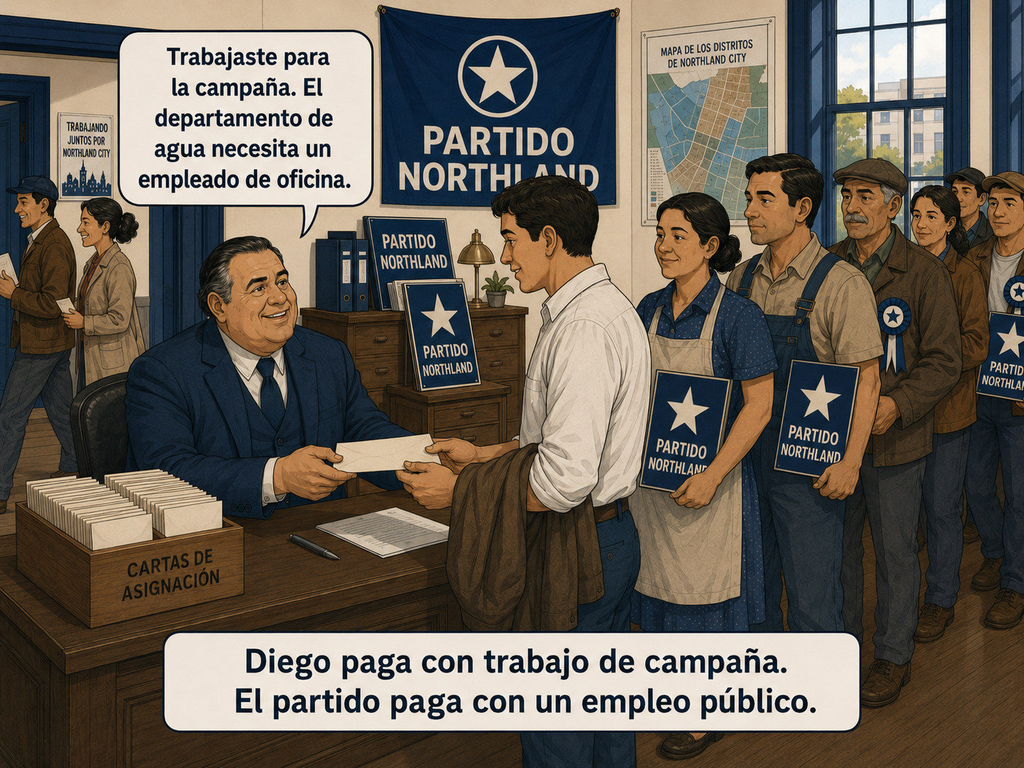

No hay dinero de por medio. Nada se oculta. Nadie se avergüenza.

**Entonces, ¿por qué le daría el partido ese puesto a Diego?**

## Porque el puesto es el combustible

```
%%{init: {"theme": "base", "width": 1150, "height": 560, "fontSize": 16, "themeVariables": {"fontSize": "16px", "fontFamily": "Helvetica, Arial, sans-serif", "primaryColor": "#eef2f6", "primaryTextColor": "#1e293b", "primaryBorderColor": "#334155", "lineColor": "#b44527", "edgeLabelBackground": "#f9…
flowchart LR
  A["EL PARTIDO GANA"]
  B["CONTROLA LOS EMPLEOS<br/>Y LOS CONTRATOS"]
  C["EMPLEOS A PARTIDARIOS,<br/>CONTRATOS A AMIGOS"]
  D["REGRESAN TRABAJO DE CAMPAÑA,<br/>VOTOS Y DINERO"]
  A --> B
  B --> C
  C --> D
  D -- "y así vuelve a ganar" --> A
  classDef step fill:#eef2f6,stroke:#334155,stroke-width:2px,color:#1e293b;
  class A,B,C,D step;
```

Empleados civiles federales: **53,000 en 1871 → 256,000 en 1901.**

**La moneda de la maquinaria era el empleo público — y ese empleo era dinero público.**

Skowronek (1982, cap. 3). A los empleados también se les “cobraba cuota” — un descuento sobre su salario para financiar las campañas que mantenían al partido en el poder.

## ¿Cómo lo romperías?

Sacar los empleos de las manos de los políticos.

- En Estados Unidos eso fue la **reforma del servicio civil** — la Ley Pendleton de 1883.
- Contratación por examen abierto y competitivo, en lugar de por el partido.
- Cubría el **11%** de los puestos federales.
- La aplicación, y cualquier ampliación de esa cobertura, quedó en manos del Presidente.

## Diego, veinte años después

Algunos puestos ahora exigen examen. Diego no habría conseguido uno de esos por la vía del partido. Pero la maquinaria sigue llenando los demás.

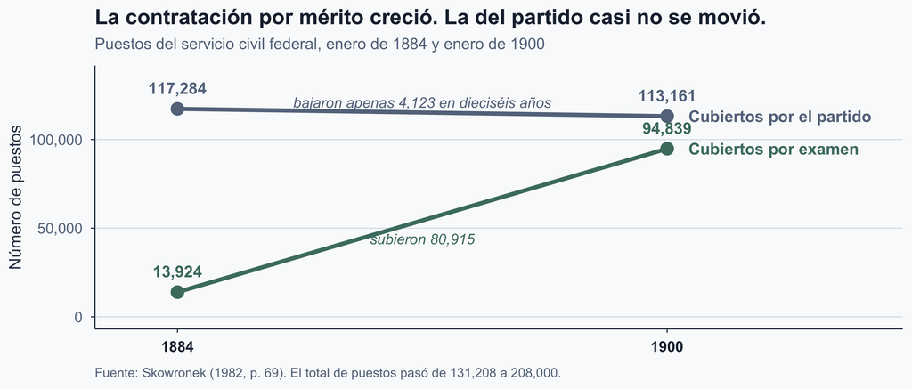

El examen no le **quitó** puestos a la maquinaria. El total pasó de 131,208 a 208,000 — y la contratación por mérito cubrió los nuevos.

**La reforma creció junto a la maquinaria en vez de reemplazarla.** Diecinueve de cada veinte puestos nuevos por mérito vinieron del crecimiento, no de un empleo que el partido hubiera soltado.

## ¿Y entonces?

- La reforma del servicio civil atacó el mismo mecanismo que la constitución general de sociedades: **sacar un favor valioso de las manos de los políticos**
- Pero la Ley Pendleton solo lo hizo parcialmente — la mayoría de los puestos federales siguió disponible para el patronazgo
- En las décadas siguientes, las reglas de mérito se extendieron de manera desigual, sobre todo en los **gobiernos municipales**

Eso nos da algo que podemos poner a prueba. Si los empleos públicos dejan de depender del partido, ¿deberían los funcionarios comportarse distinto?

## Ejercicio 2 · Un puesto público

La ciudad tiene **una plaza de oficinista** que cubrir.

Los tres aspirantes están calificados.

| Aspirante | Trabajadores de campaña que aporta |
| --- | --- |
| Ana | 2 |
| Bruno | 8 |
| Carla | 20 |

Eres el jefe del partido.

**¿Quién se queda con el puesto?**

## Claro que elegiste a Carla

¿Por qué?

No porque sea la mejor oficinista. Porque el empleo público te compra 20 trabajadores de campaña.

**El puesto se volvió moneda política.**

**Y no eres la excepción.** Nadie aquí tuvo que ser codicioso para elegir a Carla — dale a cualquiera el control de un beneficio público escaso y descubrirá cómo usarlo políticamente. **El trabajo lo hace el arreglo, no el carácter.**

## Ahora cambia una sola regla

Mismo puesto. Mismos aspirantes. Mismo jefe del partido.

Pero ahora los aspirantes presentan un examen:

| Aspirante | Trabajadores de campaña | Calificación |
| --- | --- | --- |
| Ana | 2 | **92** |
| Bruno | 8 | 81 |
| Carla | 20 | 74 |

¿Quién se queda con el puesto ahora?

## ¿Qué desapareció?

El puesto no desapareció.

El político no se volvió más honesto.

El partido sigue queriendo ganar.

Pero el jefe ya no puede decirle a Carla: “Apóyame y te doy el puesto”.

La reforma eliminó la **discrecionalidad del político**.

## Conclusión

**Estados Unidos no se volvió más limpio porque llegara gente mejor. Se volvió más limpio porque había menos que vender.**

Tomó cincuenta años, y nunca fue completo.

## Referencias

Gibson, C. (1998). *Population of the 100 largest cities and other urban places in the United States: 1790 to 1990* (Population Division Working Paper No. 27). U.S. Census Bureau. https://www.census.gov/library/working-papers/1998/demo/POP-twps0027.html

Glaeser, E. L., & Goldin, C. (2006). Corruption and reform: An introduction. In E. L. Glaeser & C. Goldin (Eds.), *Corruption and reform: Lessons from America’s economic history* (pp. 3–22). University of Chicago Press.

Rauch, J. E. (1995). Bureaucracy, infrastructure, and economic growth: Evidence from U.S. cities during the Progressive Era. *American Economic Review, 85*(4), 968–979.

Skowronek, S. (1982). *Building a new American state: The expansion of national administrative capacities, 1877–1920*. Cambridge University Press.

Underhill, I. (1914). *Tammany Hall & 14th St. West, New York City* [Photograph]. Library of Congress, Prints & Photographs Division (LC-USZ62-101734).

Wallis, J. J. (2006). The concept of systematic corruption in American history. In E. L. Glaeser & C. Goldin (Eds.), *Corruption and reform: Lessons from America’s economic history* (pp. 23–62). University of Chicago Press.